# SSD1 motifs in Aspergillus Nidulans & similarities with Aspergillus Fumigatus

Tristan

04/07/2023

### Summary

In this doc we look for the *CNYTCNYT* Ssd-1 binding motif in Aspergillus Nidulans. We also look for similarities between those genes with significant motifs and the genes with significant motifs in Aspergillus Fumigatus.

## Aspergillus Nidulans motif analysis

### Load 1000nt UTRs from Aspergillus Nidulans

```r
#load data
# define fasta filename
As_up1000_file <- paste(here::here(),
                        "data",
                        "RNA",
                        "Asp_Ni_999.fasta",
                        sep= "/")

# load fasta file as DNA string set
As_up1000_DSS <- readDNAStringSet(As_up1000_file)

# remove truncated sequences, which we don't need.
As_up1000_DSS <- As_up1000_DSS[width(As_up1000_DSS) == 1000]

# assign just the ORF id to the name, but keep all the info.
As_namesinfo <-
    tibble(everything = names(As_up1000_DSS)) %>%
    tidyr::separate(everything,into = c("id","strain","info","seqtype","seq","length"), sep = " \\| ") %>%
    dplyr::select(id, info,seq)
```

### Count occurences of *CNYTCNYT* motif in Aspergillus Nidulans

```r
CNYTCNYT_count_df <- tibble(id = As_namesinfo$id,
                            info = As_namesinfo$info,
                            count_up1000 = vcountPattern(pattern = DNAString("CNYTCNYT"),
                                 subject = As_up1000_DSS,
                                 fixed = "subject"),
                            count_up200 = vcountPattern(pattern = DNAString("CNYTCNYT"),
                                 subject = subseq(As_up1000_DSS,start = 801L, end = 1000L),
                                 fixed = "subject"),
                            count_up100 = vcountPattern(pattern = DNAString("CNYTCNYT"),
                                 subject = subseq(As_up1000_DSS,start = 901L, end = 1000L),
                                 fixed = "subject")
)
arrange(CNYTCNYT_count_df,desc(count_up100)) %>%
    head(n = 20) %>%
    knitr::kable()
```

| id | info | count_up1000 | count_up200 | count_up100 |
| --- | --- | --- | --- | --- |
| AN8881 | Predicted siderophore transporter | 12 | 8 | 8 |
| AN5214 | Endo-beta-1,4-glucanase B | 9 | 8 | 8 |
| AN4882 | Putative pectin lyase involved in degradation of pectin | 6 | 6 | 6 |
| AN7229 | Transcript induced in response to calcium dichloride in a CrzA-dependent manner | 8 | 6 | 6 |
| AN8319 | protein of unknown function | 6 | 6 | 6 |
| AN5692 | Ortholog(s) have role in peroxisome organization and integral component of peroxisomal membrane, plasma membrane localization | 6 | 6 | 6 |
| AN1602 | Putative beta-1,4-endoglucanase | 9 | 7 | 6 |
| AN8327 | Protein with polygalacturonase activity, involved in degradation of pectin | 7 | 6 | 6 |
| AN6656 | Putative enodopolygalacturonase | 7 | 5 | 5 |
| AN4821 | Has domain(s) with predicted DNA binding, zinc ion binding activity, role in transcription, DNA-templated and nucleus localization | 7 | 5 | 5 |
| AN7541 | Cutinase 2 | 5 | 5 | 5 |
| AN1196 | Ortholog(s) have mitochondrion localization | 7 | 5 | 5 |
| AN4438 | Ortholog of A. nidulans FGSC A4 : AN4246, AN8484, A. fumigatus Af293 : Afu1g06480, Afu2g05150/mp2, A. niger CBS 513.88 : An18g05510 and A. oryzae RIB40 : AO090001000450 | 11 | 10 | 5 |
| AN10880 | Ortholog(s) have proteasome binding activity, role in cellular response to arsenic-containing substance, proteasome-mediated ubiquitin-dependent protein catabolic process and cytoplasm, nucleus locali… | 5 | 5 | 5 |
| AN0988 | Dual specificity protein kinase, putative | 7 | 5 | 5 |
| AN5931 | Putative ATP-dependent RNA helicase | 10 | 10 | 5 |
| AN7873 | Putative multifunctional enzyme with a predicted role in cytosolic fatty acid formation | 7 | 6 | 5 |
| AN6286 | Ortholog(s) have cytoplasm localization | 5 | 5 | 5 |
| AN10815 | Has domain(s) with predicted oxidoreductase activity and role in metabolic process | 4 | 4 | 4 |
| AN4668 | Putative mitogen activated protein kinase (MAPK) | 5 | 4 | 4 |

This is a table of the genes with the highest counts in the 1000nt UTRs, 200nt UTRs and 100nt UTRs, sorted by the count in the 100nt UTRs.

### 100nt upstream

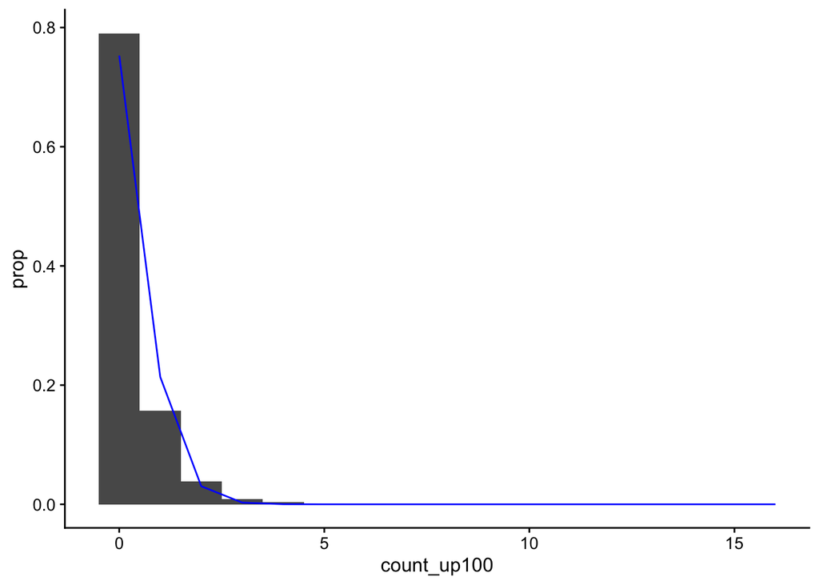

```r
# plots of counts to 100bp upstream
CNYT_up100_reducedmean <- CNYTCNYT_count_df %>%
    pull(count_up100) %>%
    mean()
CNYT_up100_reducedvar <- CNYTCNYT_count_df %>%
    pull(count_up100) %>%
    var()
ggplot(data = CNYTCNYT_count_df, aes(x = count_up100)) +
    geom_bar(width = 1, aes(y = after_stat(prop)), stat = "count", group = 1) +
    geom_line(data = tibble(),
              aes(x = 0:20, y = dpois(0:20,lambda=CNYT_up100_reducedmean)),
              colour = "blue") +
    scale_x_continuous(limits = c(-0.5,16), oob = scales::squish)
```

## Comparison of Aspergillus Nidulans and Fumigatus GO terms

Following this, I did a GO term search on fungidb using the genelists of genes with ≥ 2 *CNYTCNYT* motifs in the 100nt UTRs of Aspergillus Nidulans and Aspergillus Fumigatus.

```r
dat_file <- paste(here::here(),
                        "data",
                        "GO",
                        sep= "/")

#load data
ASP_N_GO <- read_csv(paste(dat_file, "ASP_N_motif.csv", sep= "/")) %>%
    mutate(From = "Aspergillus Nidulans")
ASP_F_GO <- read_csv(paste(dat_file, "ASP_F_motif.csv", sep= "/")) %>%
    mutate(From = "Aspergillus Fumigatus")
```

After loading in both GO Enrichment files, you can see that Aspergillus Nidulans has 12 GO terms with a p-value of < 0.05, whereas Aspergillus Fumigatus has 11 GO terms with a p-value of < 0.05. They have an overlap of 9 GO terms.

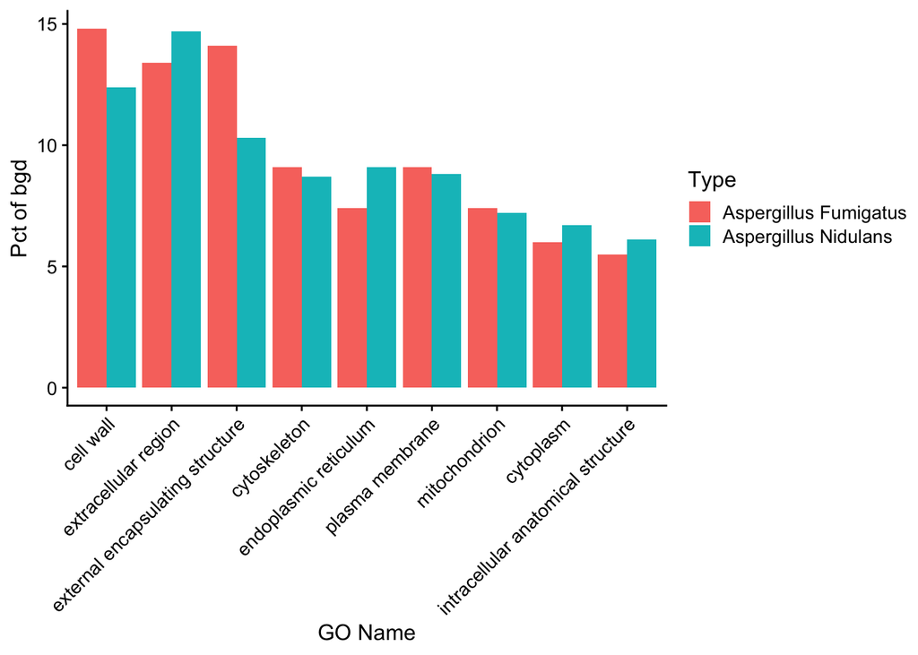

```r
#find overlap in GO names
overlap <- intersect(ASP_N_GO$Name, ASP_F_GO$Name)

#plot bar chart of "Pct of bgd" for each GO name in overlap from both ASP_N_GO and ASP_F_GO
combined <- rbind(ASP_F_GO, ASP_N_GO)
combined <- combined[combined$Name %in% overlap,]

ggplot(combined, aes(x = reorder(Name, -`Pct of bgd`, FUN = min), y = `Pct of bgd`, group = From, fill = From)) +
    geom_bar(stat = "identity", position = "dodge") +
    theme(axis.text.x = element_text(angle = 45, hjust = 1)) +
    labs(x = "GO Name", y = "Pct of bgd", fill = "Type")
```

This shows that the GO terms of the targeted genes in Aspergillus Nidulans and Aspergillus Fumigatus are similar, with cell wall having lower representation in Aspergillus Nidulans but extracellular region having higher representation.